# Flexible Damage Functions

Author

James Rising, Sebastian Cadavid Sanchez, Climate Impact Lab

Published

April 30, 2026

## 0.1 Agriculture: Wheat Combined Country

Flexible damage function parameters at the Country level.

**Change in wheat yields (log change in yields) under full adaptation**

**Outcome units:** `physical` — log change in wheat combined yield (population-weighted to country)

$$D_{it} = (\alpha_i T_t + \beta_i T_t^2) \cdot Y_{it}^{\gamma}$$

where $\gamma$ is the income elasticity (fitted globally), $\alpha_i$ is the linear coefficient, and $\beta_i$ is the quadratic coefficient.

# 1 Global Estimation

## 1.1 Income Elasticity Estimation

The income elasticity $\gamma$ is estimated using a fixed-effects regression:

$$y_{it} = \gamma \cdot \log(Y_{it}) + \mu_{g(i,T)} + \nu_t + \varepsilon_{it}$$

where $\mu_{g(i,T)}$ are region-by-temperature-bin fixed effects and $\nu_t$ are year fixed effects.

Table 1: Income Elasticity (Gamma) Estimation Results

| Statistic | Value |
| --- | --- |
| Income elasticity ($\gamma$) | -0.0358 |
| Standard error | 8.52e-03 |
| 95% CI | [-0.0525, -0.0191] |
| R-squared | 0.4354 |
| Observations | 2,870,303 |
| Regions | 138 |
| Gamma quantiles | 19 |

# 2 Parameter Distributions

## 2.1 8-Panel Summary

Row 1: gamma, alpha, beta, rsqr1. Row 2: rho, zeta, eta, rsqr2.

```
Using median gamma: -0.035821, 138 rows (of 2,622 total)
```

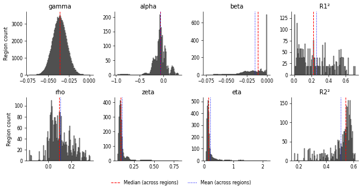

Figure 1: Distribution of Regional Parameters

## 2.2 Projection Equation and Parameter Definitions

The estimated parameters are used to project damages via Monte Carlo sampling:

$$D_{it}^k = (\hat{\alpha}_{ik} T_t + \hat{\beta}_{ik} T_t^2) Y_{it}^{\hat{\gamma}_k} + \hat{\theta}_{ik} T_t Y_{it}^{\hat{\gamma}_k} + \hat{\phi}_{it}^k$$

where $k$ indexes the Monte Carlo draw. The parameters in each row of the output CSV control distinct components of this equation:

- **gamma**: income elasticity $\hat{\gamma}_k$, one of 19 quantile values drawn from $N(\hat{\gamma}, SE(\hat{\gamma}))$
- **alpha, beta**: linear and quadratic temperature coefficients; $\hat{\alpha}_{ik}$ and $\hat{\beta}_{ik}$ are drawn from the joint normal defined by the VCV below
- **sigma11, sigma12, sigma22**: variance-covariance matrix of $(\alpha, \beta)$, used for joint uncertainty sampling
- **rho**: correlation between regional and global polynomial residuals $\rho_i$, used to maintain spatial covariance across regions in Monte Carlo draws
- **zeta**: temperature-dependent error scale $\zeta_{ik}$; the run-specific error term $\hat{\theta}_{ik}$ is drawn from $N(0, \zeta_{ik})$
- **eta**: residual noise standard deviation $\eta_{ik}$; the annual noise $\hat{\phi}_{it}^k$ is drawn from $N(0, \eta_{ik})$
- **rsqr1, rsqr2**: polynomial fit quality and error model fit, respectively

## 2.3 Summary Statistics

Table 2: Regional Parameter Summary

[output not shown]

# 3 Spaghetti Curves

Regional damage function curves showing D(T) = αT + βT² for sampled regions.

[interactive chart not shown]

Figure 2: Regional Damage Functions

# 4 Zero Crossings

The zero crossing (extremum) of the parabola occurs at $T^* = -\alpha / (2\beta)$.

Table 3: Zero Crossing Statistics

| Category | Count | Percentage |
| --- | --- | --- |
| β = 0 (no crossing) | 36 | 26.1% |
| T > 20°C (beyond graph) | 0 | 0.0% |
| T < 0°C (negative crossing) | 69 | 50.0% |
| Valid crossings (0-20°C) | 33 | 23.9% |

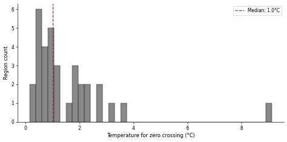

Figure 3: Distribution of Zero Crossing Temperatures

# 5 Slope Analysis

Maximum slope between 0 and 10°C: $\frac{dM}{dT} = \alpha + 2\beta T$

The maximum occurs at either T=0 or T=10 (endpoints of interval).

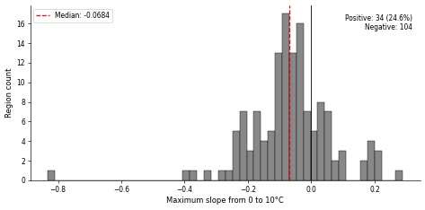

Figure 4: Distribution of Maximum Slopes (0-10°C)

*Convexity analysis omitted (beta constraint active).*

# 6 R-squared Analysis

## 6.1 Polynomial Fit Quality (rsqr1)

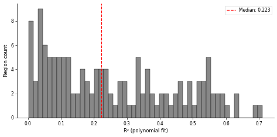

Figure 5: Regional Fit Quality (R-squared)

## 6.2 Error Model R-squared (rsqr2) Quantiles

Table 4: rsqr2 Quantiles

| 0% (Min) | 25% | 50% (Median) | 75% | 100% (Max) |
| --- | --- | --- | --- | --- |
| 0.1705 | 0.4866 | 0.5415 | 0.5678 | 0.6108 |

# 7 Modelled Variance

Modelled variance statistic: $1 - \frac{\sum_i \eta_i^2}{\sum_i D_i^2}$

Table 5: Modelled Variance Statistics

| Statistic | Value |
| --- | --- |
| Modelled variance | 0.5675 |
| Sum(η²) | 13.5894 |
| Sum(D²) at T=3.0°C | 31.4187 |
| N regions | 138 |

# 8 Best- and Worst-Fitting Regions

Table 6: Best- and worst-fitting regions

Top 3 best fit (R²) Top 3 worst fit (R²)

| Region | α | β | η | R² |
| --- | --- | --- | --- | --- |
| CHE | -0.196 | -0.0163 | 0.116 | 0.71 |
| HRV | -0.169 | -0.00238 | 0.0938 | 0.627 |
| MNE | -0.15 | -0.00981 | 0.106 | 0.605 |
| CAF | -0.00357 | -0.00215 | 0.153 | 0.0041 |
| PAK | 0.0664 | -0.0172 | 0.231 | 0.00607 |
| MYS | 0.0345 | -0.0168 | 0.409 | 0.0078 |

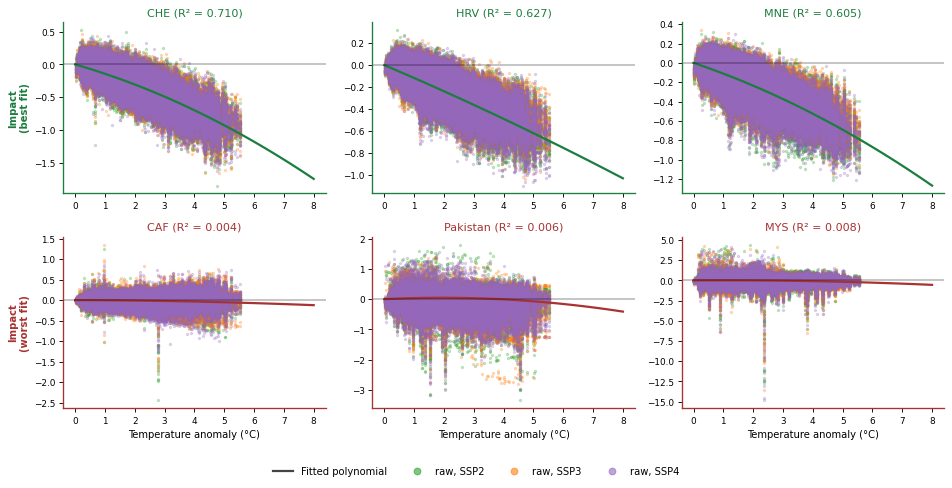

# 9 Regional Parameter Maps

Maps of key parameters at the **country** level. Red = negative (damage increases with T), Blue = positive.

## 9.1 Alpha (Linear Coefficient)

Alpha ($\alpha$) represents the linear sensitivity to temperature. Regions with negative alpha experience damage that increases with the first degree of warming.

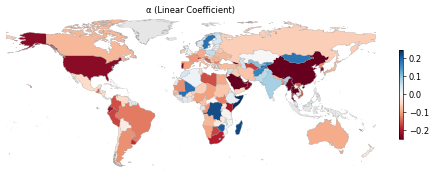

Figure 7: α (linear coefficient)

## 9.2 Beta (Quadratic Coefficient)

Beta ($\beta$) represents the curvature of the damage function.

The concavity ($\beta \leq 0$) constraint is enforced for this sector, meaning optimal temperature exists, damages accelerate beyond it.

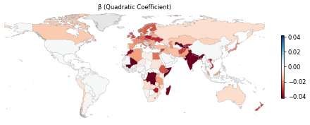

Figure 8: β (quadratic coefficient)

## 9.3 R-squared (Fit Quality)

$R^2$ measures the polynomial fit quality. Higher values indicate that the quadratic form captures more of the variance in the data.

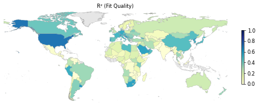

Figure 9: R² (stage 1 fit quality)

# 10 F2: Flex vs Raw Comparison

Comparison of flexible damage function predictions against raw simulation means.

For each scenario (RCP × SSP × Model), we compute at the final year:

- **Flex predicted**: $(\alpha \cdot T + \beta \cdot T^2) \cdot Y^\gamma$
- **Raw actual**: The outcome variable (y) from the source data

**Year 2098**: 1,457,280 rows

**rcp45**

**SSP2**

**high**

**Correlation:** 0.7723 | **RMSE:** 0.118541 | **Sign agreement:** 90.6%

[interactive chart not shown]

Top 5 best predicted Top 5 worst predicted

Year 2098 · T<sub>mean</sub> across these regions: 1.94°C

| Region | Raw | Flex | Residual |
| --- | --- | --- | --- |
| GUY | 0.0375 | 0.0373 | -2.28e-4 |
| IRN | -0.124 | -0.122 | 0.00229 |
| MYS | 0.00494 | 0.00253 | -0.00241 |
| BFA | -0.0617 | -0.0591 | 0.00261 |
| LBY | -0.207 | -0.211 | -0.0034 |
| IND | -0.406 | 0.00191 | 0.408 |
| ZWE | -0.172 | 0.188 | 0.359 |
| MDG | -0.145 | 0.19 | 0.335 |
| COD | -0.164 | 0.157 | 0.321 |
| VNM | -0.597 | -0.283 | 0.314 |

**low**

**Correlation:** 0.7904 | **RMSE:** 0.106477 | **Sign agreement:** 89.1%

[interactive chart not shown]

Top 5 best predicted Top 5 worst predicted

Year 2098 · T<sub>mean</sub> across these regions: 1.94°C

| Region | Raw | Flex | Residual |
| --- | --- | --- | --- |
| GTM | -0.188 | -0.188 | 1.65e-4 |
| MMR | -0.54 | -0.54 | -2.10e-4 |
| AZE | -0.104 | -0.107 | -0.00348 |
| TUR | -0.129 | -0.134 | -0.00548 |
| PRY | -0.142 | -0.149 | -0.00721 |
| IND | -0.37 | 0.00192 | 0.372 |
| VNM | -0.588 | -0.285 | 0.303 |
| COD | -0.135 | 0.159 | 0.294 |
| MDG | -0.0849 | 0.2 | 0.285 |
| SOM | -0.0467 | 0.231 | 0.278 |

**SSP3**

**high**

**Correlation:** 0.7640 | **RMSE:** 0.105206 | **Sign agreement:** 90.6%

[interactive chart not shown]

Top 5 best predicted Top 5 worst predicted

Year 2098 · T<sub>mean</sub> across these regions: 1.94°C

| Region | Raw | Flex | Residual |
| --- | --- | --- | --- |
| LTU | -0.0586 | -0.0578 | 8.09e-4 |
| PRY | -0.149 | -0.15 | -9.42e-4 |
| SLV | -0.0869 | -0.0889 | -0.00201 |
| BGR | -0.191 | -0.195 | -0.00427 |
| BRA | -0.179 | -0.174 | 0.00467 |
| IND | -0.37 | 0.00199 | 0.372 |
| SOM | -0.0948 | 0.258 | 0.353 |
| MDG | -0.0956 | 0.199 | 0.294 |
| ZWE | -0.0681 | 0.195 | 0.264 |
| THA | -0.231 | -0.493 | -0.262 |

**low**

**Correlation:** 0.7505 | **RMSE:** 0.107669 | **Sign agreement:** 89.9%

[interactive chart not shown]

Top 5 best predicted Top 5 worst predicted

Year 2098 · T<sub>mean</sub> across these regions: 1.94°C

| Region | Raw | Flex | Residual |
| --- | --- | --- | --- |
| MNG | 0.223 | 0.223 | 2.77e-4 |
| ARM | -0.111 | -0.112 | -5.93e-4 |
| GUY | 0.0403 | 0.0391 | -0.00125 |
| CHL | -0.0796 | -0.0809 | -0.0013 |
| BOL | -0.0298 | -0.0275 | 0.00227 |
| SOM | -0.0891 | 0.248 | 0.337 |
| IND | -0.311 | 0.00198 | 0.313 |
| BTN | -0.822 | -1.11 | -0.289 |
| THA | -0.216 | -0.498 | -0.283 |
| MDG | -0.0552 | 0.211 | 0.266 |

**SSP4**

**high**

**Correlation:** 0.7629 | **RMSE:** 0.111616 | **Sign agreement:** 88.4%

[interactive chart not shown]

Top 5 best predicted Top 5 worst predicted

Year 2098 · T<sub>mean</sub> across these regions: 1.94°C

| Region | Raw | Flex | Residual |
| --- | --- | --- | --- |
| IRN | -0.121 | -0.122 | -9.84e-4 |
| TUR | -0.133 | -0.134 | -0.00118 |
| GUY | 0.036 | 0.0372 | 0.00123 |
| HND | -0.056 | -0.0545 | 0.00155 |
| ARM | -0.11 | -0.112 | -0.00173 |
| SOM | -0.205 | 0.27 | 0.475 |
| IND | -0.397 | 0.00192 | 0.399 |
| VNM | -0.601 | -0.284 | 0.317 |
| MDG | -0.075 | 0.202 | 0.277 |
| ZWE | -0.0636 | 0.197 | 0.261 |

**low**

**Correlation:** 0.7412 | **RMSE:** 0.109132 | **Sign agreement:** 89.9%

[interactive chart not shown]

Top 5 best predicted Top 5 worst predicted

Year 2098 · T<sub>mean</sub> across these regions: 1.94°C

| Region | Raw | Flex | Residual |
| --- | --- | --- | --- |
| JOR | -0.0474 | -0.0486 | -0.00124 |
| CA- | 0.0112 | 0.0147 | 0.00352 |
| NIC | -0.0624 | -0.0583 | 0.00413 |
| ARG | -0.157 | -0.153 | 0.0044 |
| LTU | -0.0531 | -0.0581 | -0.00495 |
| BTN | -0.77 | -1.11 | -0.343 |
| IND | -0.321 | 0.00197 | 0.323 |
| THA | -0.19 | -0.499 | -0.31 |
| MMR | -0.278 | -0.585 | -0.307 |
| SOM | -0.0372 | 0.24 | 0.278 |

**rcp85**

**SSP2**

**high**

**Correlation:** 0.8596 | **RMSE:** 0.192650 | **Sign agreement:** 94.9%

[interactive chart not shown]

Top 5 best predicted Top 5 worst predicted

Year 2098 · T<sub>mean</sub> across these regions: 4.17°C

| Region | Raw | Flex | Residual |
| --- | --- | --- | --- |
| VNM | -0.809 | -0.81 | -0.00142 |
| CA- | -0.0927 | -0.09 | 0.00273 |
| IRQ | -0.339 | -0.342 | -0.00285 |
| RUS | -0.243 | -0.246 | -0.00289 |
| PRY | -0.318 | -0.311 | 0.00706 |
| BGD | -1.85 | -1.08 | 0.767 |
| NPL | -1.67 | -0.908 | 0.761 |
| IND | -0.881 | -0.255 | 0.626 |
| ZWE | -0.312 | 0.19 | 0.503 |
| MAR | -0.777 | -0.307 | 0.47 |

**low**

**Correlation:** 0.8833 | **RMSE:** 0.161161 | **Sign agreement:** 94.2%

[interactive chart not shown]

Top 5 best predicted Top 5 worst predicted

Year 2098 · T<sub>mean</sub> across these regions: 4.17°C

| Region | Raw | Flex | Residual |
| --- | --- | --- | --- |
| IRN | -0.342 | -0.345 | -0.00302 |
| EST | -0.236 | -0.232 | 0.00444 |
| UZB | -0.227 | -0.233 | -0.00605 |
| YEM | -0.149 | -0.142 | 0.00768 |
| USA | -0.595 | -0.606 | -0.0104 |
| NPL | -1.54 | -0.932 | 0.613 |
| IND | -0.85 | -0.257 | 0.593 |
| BGD | -1.67 | -1.12 | 0.546 |
| THA | -0.612 | -1.05 | -0.435 |
| COD | -0.375 | 0.00215 | 0.378 |

**SSP3**

**high**

**Correlation:** 0.8773 | **RMSE:** 0.151833 | **Sign agreement:** 94.2%

[interactive chart not shown]

Top 5 best predicted Top 5 worst predicted

Year 2098 · T<sub>mean</sub> across these regions: 4.17°C

| Region | Raw | Flex | Residual |
| --- | --- | --- | --- |
| NIC | -0.119 | -0.122 | -0.00296 |
| SVN | -0.681 | -0.677 | 0.00389 |
| LVA | -0.147 | -0.141 | 0.00647 |
| ALB | -0.318 | -0.325 | -0.00728 |
| PSE | -0.314 | -0.306 | 0.00779 |
| THA | -0.531 | -1.06 | -0.529 |
| IND | -0.739 | -0.267 | 0.472 |
| BTN | -1.93 | -2.34 | -0.41 |
| BGD | -1.51 | -1.13 | 0.382 |
| SOM | -0.28 | 0.0864 | 0.366 |

**low**

**Correlation:** 0.8854 | **RMSE:** 0.150984 | **Sign agreement:** 92.8%

[interactive chart not shown]

Top 5 best predicted Top 5 worst predicted

Year 2098 · T<sub>mean</sub> across these regions: 4.17°C

| Region | Raw | Flex | Residual |
| --- | --- | --- | --- |
| ROU | -0.433 | -0.432 | 6.56e-4 |
| PRK | -0.465 | -0.468 | -0.00349 |
| ETH | -0.283 | -0.279 | 0.00447 |
| MNE | -0.554 | -0.549 | 0.00547 |
| MNG | 0.408 | 0.414 | 0.00623 |
| THA | -0.48 | -1.07 | -0.59 |
| IND | -0.734 | -0.265 | 0.469 |
| BTN | -1.94 | -2.39 | -0.445 |
| SOM | -0.271 | 0.083 | 0.354 |
| EGY | -0.226 | -0.563 | -0.337 |

**SSP4**

**high**

**Correlation:** 0.8915 | **RMSE:** 0.153062 | **Sign agreement:** 93.5%

[interactive chart not shown]

Top 5 best predicted Top 5 worst predicted

Year 2098 · T<sub>mean</sub> across these regions: 4.17°C

| Region | Raw | Flex | Residual |
| --- | --- | --- | --- |
| PRY | -0.314 | -0.314 | 3.29e-4 |
| OMN | -0.621 | -0.622 | -0.00177 |
| HND | -0.115 | -0.117 | -0.00252 |
| NIC | -0.119 | -0.122 | -0.00357 |
| UZB | -0.228 | -0.233 | -0.00496 |
| IND | -0.85 | -0.257 | 0.593 |
| SOM | -0.417 | 0.0906 | 0.508 |
| MAR | -0.717 | -0.311 | 0.406 |
| THA | -0.66 | -1.03 | -0.372 |
| BGD | -1.5 | -1.15 | 0.357 |

**low**

**Correlation:** 0.8756 | **RMSE:** 0.154961 | **Sign agreement:** 92.0%

[interactive chart not shown]

Top 5 best predicted Top 5 worst predicted

Year 2098 · T<sub>mean</sub> across these regions: 4.17°C

| Region | Raw | Flex | Residual |
| --- | --- | --- | --- |
| KO- | -0.416 | -0.416 | -3.81e-4 |
| HRV | -0.505 | -0.504 | 7.52e-4 |
| PRK | -0.467 | -0.465 | 0.00222 |
| KAZ | -0.14 | -0.137 | 0.00227 |
| BLR | -0.361 | -0.358 | 0.00299 |
| THA | -0.488 | -1.07 | -0.585 |
| BTN | -1.92 | -2.39 | -0.469 |
| IND | -0.733 | -0.264 | 0.468 |
| TKM | -0.148 | -0.48 | -0.333 |
| MMR | -0.928 | -1.26 | -0.33 |

**Note · countries with no wheat combined data** (shown white on every map above; the GCP wheat combined pipeline does not run sims for non-producing countries): ABW, AIA, ALA, AND, ASM, ATA, ATF, ATG, BES, BHR, BHS, BLM, BMU, BRB, BRN, BVT, CCK, CIV, CL-, COK, COM, CPV, CRI, CUB, CUW, CXR, CYM, CYP, DJI, DMA, DOM, ESH, FJI, FLK, FRO, FSM, GAB, GGY, Ghana, GIB, GIN, GLP, GMB, GNB, GNQ, GRD, GRL, GUF, GUM, HKG, HMD, HTI, Indonesia, IMN, IOT, ISL, JAM, JEY, KHM, KIR, KNA, LBR, LCA, LIE, LKA, MAC, MAF, MCO, MDV, MHL, MNP, MSR, MTQ, MUS, MYT, NFK, NIU, NRU, PAN, PCN, Philippines, PLW, PNG, PRI, PYF, QAT, REU, SGP, SGS, SHN, SJM, SLB, SLE, SMX, SP-, SPM, STP, SUR, SYC, TCA, TGO, TKL, TLS, TON, TTO, TUV, TWN, UMI, VAT, VCT, VGB, VIR, VUT, WLF, WSM.

## 10.1 Scenario Summary

Table 7: Fit statistics across all 12 scenarios

| RCP | SSP | Model | N | Corr | RMSE | Sign% |
| --- | --- | --- | --- | --- | --- | --- |
| rcp45 | SSP2 | high | 138 | 0.7723 | 0.118541 | 90.6% |
| rcp45 | SSP2 | low | 138 | 0.7904 | 0.106477 | 89.1% |
| rcp45 | SSP3 | high | 138 | 0.764 | 0.105206 | 90.6% |
| rcp45 | SSP3 | low | 138 | 0.7505 | 0.107669 | 89.9% |
| rcp45 | SSP4 | high | 138 | 0.7629 | 0.111616 | 88.4% |
| rcp45 | SSP4 | low | 138 | 0.7412 | 0.109132 | 89.9% |
| rcp85 | SSP2 | high | 138 | 0.8596 | 0.19265 | 94.9% |
| rcp85 | SSP2 | low | 138 | 0.8833 | 0.161161 | 94.2% |
| rcp85 | SSP3 | high | 138 | 0.8773 | 0.151833 | 94.2% |
| rcp85 | SSP3 | low | 138 | 0.8854 | 0.150984 | 92.8% |
| rcp85 | SSP4 | high | 138 | 0.8915 | 0.153062 | 93.5% |
| rcp85 | SSP4 | low | 138 | 0.8756 | 0.154961 | 92.0% |

# 11 Data Reference

## 11.1 File Locations

| Item | Path |
| --- | --- |
| Regional CSV | `/project/cil/gcp/flex_damage_funcs/parameters/agriculture__wheat_combined_country__regional_parameters.csv` |
| Global JSON | `/project/cil/gcp/flex_damage_funcs/parameters/agriculture__wheat_combined_country__global_results.json` |
| Metadata JSON | `/project/cil/gcp/flex_damage_funcs/parameters/agriculture__wheat_combined_country__metadata.json` |

## 11.2 Column Definitions

| Column | Description |
| --- | --- |
| `region` | Region identifier (hierarchical code, first 3 chars = country ISO3) |
| `gamma` | Income elasticity quantile value |
| `alpha` | Linear temperature coefficient |
| `beta` | Quadratic temperature coefficient |
| `sigma11` | Var(alpha) |
| `sigma12` | Cov(alpha, beta) |
| `sigma22` | Var(beta) |
| `rho` | Correlation with global residual process |
| `zeta` | Temperature-dependent heteroskedasticity |
| `eta` | Residual standard deviation |
| `rsqr1` | R-squared of polynomial fit |
| `rsqr2` | R-squared of error model |

*Report generated with FlexDamage v1.0.0*